# Simulation setup and overview

Barbara Brune

2024-07-15

```r
library(rankLME)
library(robustlmm)
```

```r
library(lme4)

library(ggplot2)
library(dplyr)
library(tidyr)
set.seed(1212)
```

```r
source("simulation_helpers.R")
```

# Introduction

In this document, we give a short introduction to the structure of the simulation studies reported in Brune, Ortner, Filzmoser (2024).

# Dataset generation

The function `raw_data()` creates a raw, uncontaminated dataset.

```r
d <- raw_data(
  n = 200,
  p = 4,
  k = 2,
  n.groups = 20,
  group_size = 10,
  predictors = "discrete",
  ranef_distribution = "normal",
  error_distribution = "normal",
  sd_b = 0.5,
  sd_eps = 1,
  sd_X = 2,
  beta = rep(1, 4)
)
```

The data object is alist of length 6, containing the design matrices `X`and `Z`, the response vector `y`, the random effects `b`, the group labels `g` and the number of groups `n.groups`.

```r
str(d)
```

```
## List of 6
##  $ X       : num [1:200, 1:4] 1 1 1 1 1 1 1 1 1 1 ...
##  $ y       : num [1:200, 1] 17.8 7.58 13.99 17.06 11.51 ...
##  $ Z       : num [1:200, 1:2] 1 1 1 1 1 1 1 1 1 1 ...
##  $ b       : num [1:2, 1:20] -0.315 0.919 0.172 -0.68 0.268 ...
##  $ g       : int [1:200] 1 1 1 1 1 1 1 1 1 1 ...
##  $ n.groups: num 20
```

Now the data can be contaminated with various types of outliers. We implemented contamination in the form of `y_outliers`, `leverage` and `breakdown`. `y_outliers()`and `leverage()` cause contamination with additive or multiplicative outliers, while `breakdown` replaces a certain proportion of the response values `y` by 1e6 to study the breakdown behavior.

```r
args(y_outliers)
```

```
## function (raw_data, outlier_proportion, outlier_level, single_outlier_type,
##     outlier_size, y_outlier_type = "mean", ...)
## NULL
```

```r
args(leverage)
```

```
## function (raw_data, outlier_proportion, outlier_level, single_outlier_type,
##     outlier_size, outlying_columns = NULL, leverage_type = "mean",
##     ...)
## NULL
```

```r
args(breakdown)
```

```
## function (raw_data, outlier_proportion, outlier_level, single_outlier_type,
##     ...)
## NULL
```

```r
d_y_outliers = y_outliers(d, outlier_proportion=0.1, outlier_level="single",
                          single_outlier_type="random", outlier_size=10, type="mean")

d_leverage = leverage(d, outlier_proportion=0.1, outlier_level="single",
                          single_outlier_type="random", outlier_size=10, type="mean")

d_breakdown = breakdown(d, outlier_proportion=0.1, outlier_level="single",
                          single_outlier_type="random", outlier_size=10, type="mean")
```

# Model fitting and comparison

- rank
- weighted_rank
- REML
- SMDM

The functions to produce simulation results can be found in the file `inst/simulation_helpers.R`.

```r
fitted_models_uncontaminated = compare_model_fits(d, with_smdm=TRUE)
fitted_models_leverage = compare_model_fits(d_leverage, with_smdm=TRUE)
fitted_models_breakdown = compare_model_fits(d_breakdown, with_smdm=TRUE)
```

```
## boundary (singular) fit: see help('isSingular')
## boundary (singular) fit: see help('isSingular')
```

```r
fitted_models_y_outliers = compare_model_fits(d_y_outliers, with_smdm=TRUE)
```

The effects of the different contamination types on the estimates can e.g. be visualized in the following plot:

```r
res = do.call("rbind", lapply(
  list(fitted_models_uncontaminated, fitted_models_y_outliers, fitted_models_breakdown, fitted_models_leverage), get_coefficients_from_model
))

res$contamination = rep(c("none", "y_outliers", "breakdown", "leverage"), each = 7)
```

```
## Warning in scale_y_log10(): log-10 transformation introduced infinite values.
```

```
## Warning: Removed 4 rows containing missing values or values outside the scale range
## (`geom_bar()`).
```

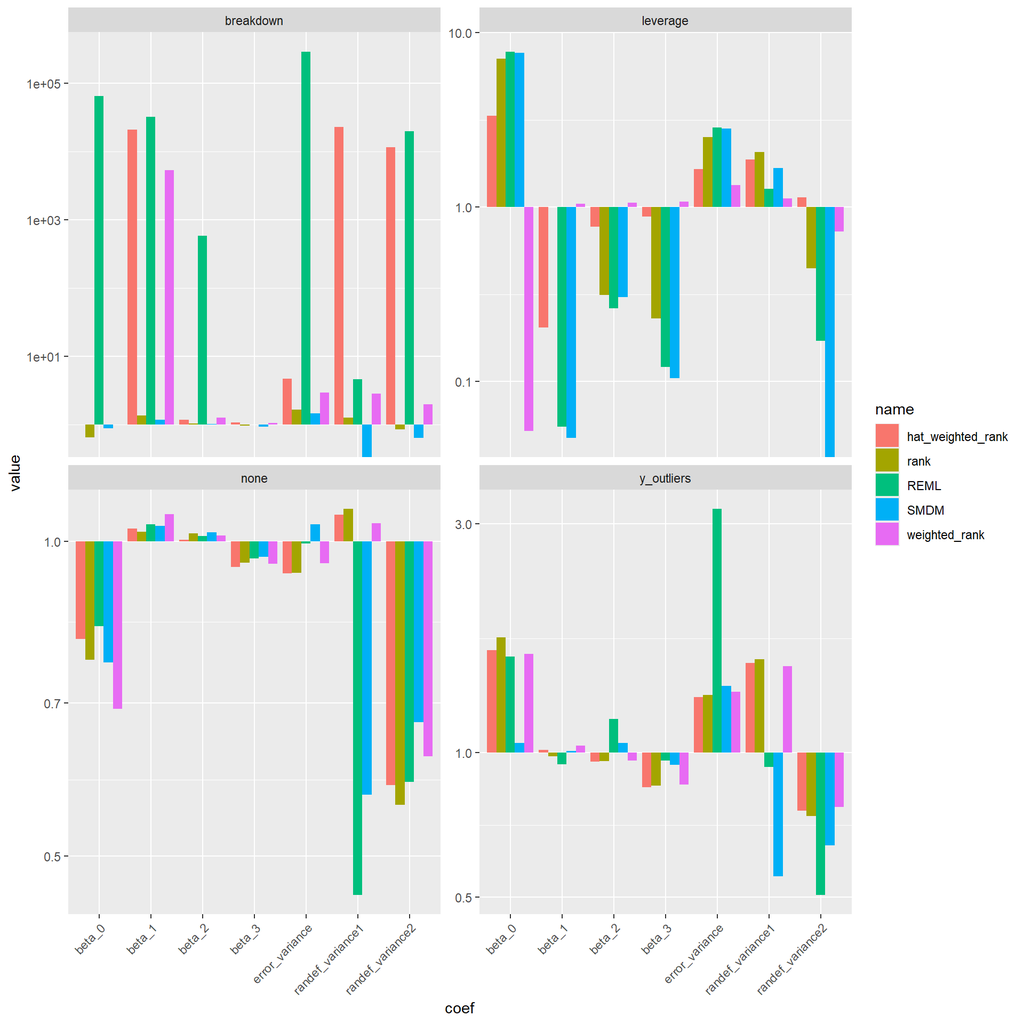

```r
res |>
  tidyr::pivot_longer(-c(contamination, coef)) |>
  ggplot(aes(coef, value, fill=name)) +
  geom_bar(stat="identity", position="dodge") +
  facet_wrap(contamination ~ ., scales="free_y") +
  scale_y_log10() +
  theme(axis.text.x = element_text(angle=45, hjust=1))
```

# Small-scale simulation run

The following code runs an exemplary simulation with multiplicative leverage outliers of different sizes. The number of replications within the for-loop can be adjusted for a larger scale simulation. The code may produce warnings since the standard REML method might run into numerical problems in the contaminated settings.

The results of the analysis can also be loaded from `inst/results_leverage.RData`.

```r
# set.seed(141414)
# sim_res = vector("list", length=length(seq(1, 20, 1)))
# run = 1
#
# for (outl_size in seq(1, 20, 1)) {
#   sim_res[[run]] =  replicate(20, replicate_model_fits(outl_size, with_smdm=TRUE), simplify=FALSE)
#   run <- run + 1
# }
```

```r
# results = do.call("rbind", lapply(sim_res, function(x) do.call("rbind", x)))
# save(results, file="results_leverage.Rdata")
```

```r
load("../results_leverage_with_hat.RData")
```

```r
mses = results |>
  group_by(method, outlier_size) |>
  summarize(across(starts_with("beta"), ~ mean((.x - 1)^2)),
            across(starts_with("theta"), ~ mean((.x - 0.5)^2)),
            sigma = mean((`sigma^2` - 1)^2))
```

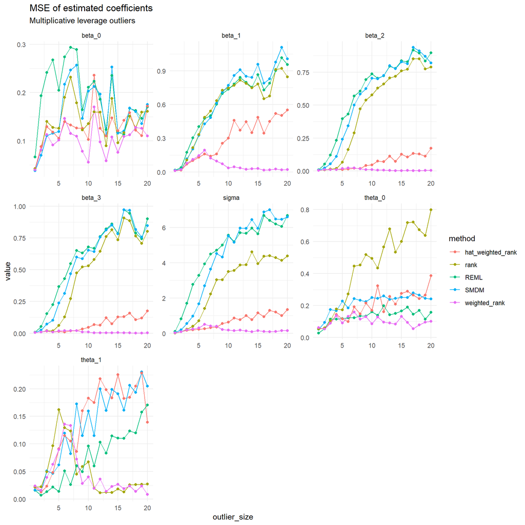

```r
mses |>
  tidyr::pivot_longer(-c(method, outlier_size)) |>
  ggplot(aes(outlier_size, value, color=method)) +
  geom_line() + geom_point() +
  facet_wrap(name ~ ., scales="free") +
  theme_minimal() +
  ggtitle("MSE of estimated coefficients",
          subtitle="Multiplicative leverage outliers")
```

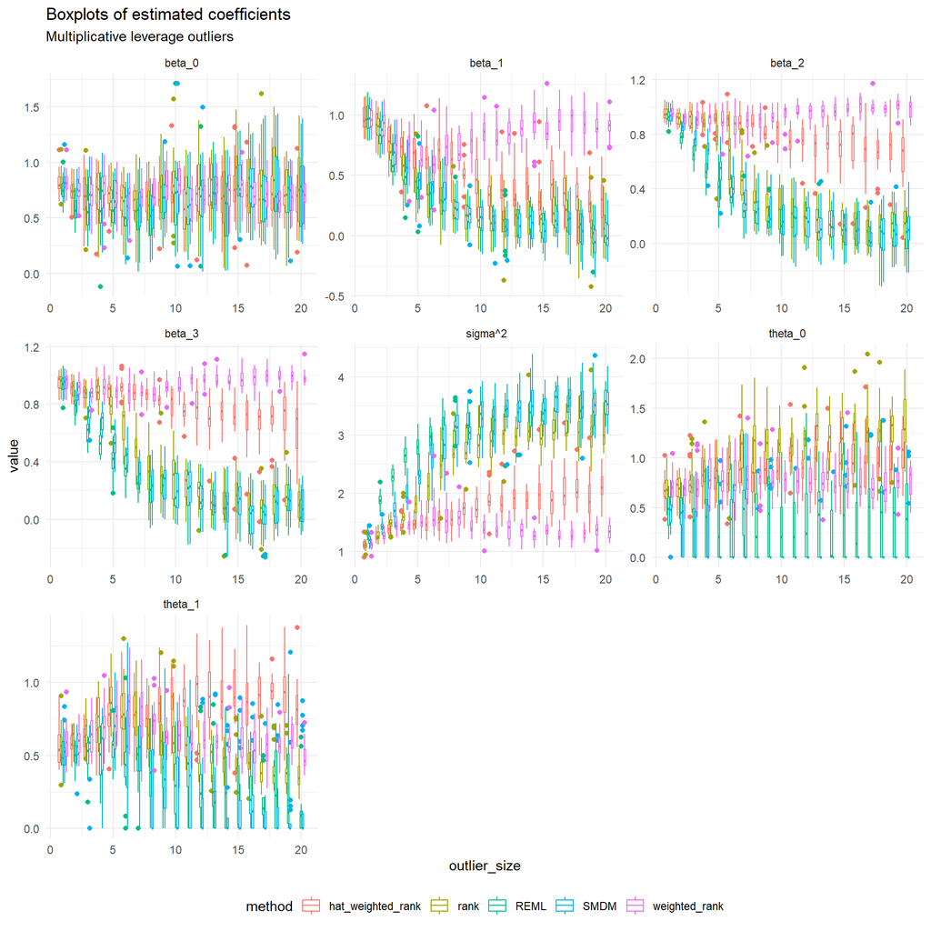

```r
results |>
  tidyr::pivot_longer(-c(method, outlier_size)) |>
  ggplot(aes(outlier_size, value, color=method, group=interaction(method, outlier_size))) +
  geom_boxplot() +
  facet_wrap(name ~ ., scales="free") +
  theme_minimal() +
  theme(legend.position="bottom") +
  ggtitle("Boxplots of estimated coefficients",
          subtitle="Multiplicative leverage outliers")
```